# Rapidfire R Introduction for Public Health

for Harris County Public Health

2023-03-28

# Introduction

This document serves as a guide and tool for the R Workshop. And it provides a way to share learning materials and other resources.

The workshop learning approach is live demonstration, with participants then doing the same steps using the materials later. There are many different approaches, resources, styles, and preferences for learning R (or anything?).

# About R and RStudio

**R** is an open source programming language for data processing, data visualization, and statistical computing.

**RStudio** is a free, open source tool that “sits on top” of R, and makes it easier and more efficient to use in all sorts of ways. Technically R Studio is an integrated development environment (IDE), that is organized so that users can clearly view graphs, data tables, R code, and outputs all at the same time.

# Since R is open source is it safe to use? What about our IT department’s concerns?

- all software has security issues
- the teams that oversee R (CRAN and RStudio) both review and test everything before it goes public and have large incentives for security
  - R and R Package Security [FAQ](https://support.rstudio.com/hc/en-us/articles/360042593974-R-and-R-Package-Security) for users or admins
- May consider only installing “official” packages from “CRAN” rather than other “local” locations like on GitHub
- At CDPH R and R Studio are approved, available, and widely used with both the “free” desktop versions and the enterprise, server-based version

# Concepts in this session

- Installing and loading R and R Studio
- R Studio console
- Using R as a calculator - mathematical operators
- R script files (“programming in R”)
- Simple data objects in R
- Built-in functions
  - arguments
  - “help” documentation
- Base R
- Reading data
- Looking at data
  - Common functions
- Installing and loading packages
  - Tidyverse
    - data wrangling
    - visualization
- Thousands of other packages
  - summarytools - easy frequencies, “cross-tables”, and summary of a data.frame
  - outbreaks - line-listed data from a bunch of real outbreaks
  - epitools
  - epikit
  - surveillance (temporal and spatio-temporal modeling and monitoring of epidemic phenomena)

# *Selected* learning resources for R and R for epidemiology

- [Hadley Wickham R for Data Science book](https://r4ds.had.co.nz/)
- Applied Epi
  - [Home](https://appliedepi.org/)
  - [The Epidemiologist R Handbook](https://www.epirhandbook.com/en/)
  - [Free self-paced tutorial series](https://appliedepi.org/tutorial/)
    - need free account
    - basics
    - data preparation
    - data cleaning
    - basics of data visualization in R
    - summary tables
- CCLHDME 2019 workshop
- [R Studio cheat sheets](https://www.rstudio.com/resources/cheatsheets/):
  - [dplyr - data wrangling cheatsheet](https://raw.githubusercontent.com/rstudio/cheatsheets/main/data-visualization.pdf)
- Google
- YouTube
- Stackoverflow
- [Rstudio community forum](https://community.rstudio.com/)

# Installing R and R Studio

Download R from the [r-project](https://cloud.r-project.org/); download the latest version suitable for your computer. Click on the downloaded file and install using all defaults.

Download RStudio from [R Studio](https://www.rstudio.com/products/rstudio/download/#download); download the latest free Desktop version of RStudio suitable for your computer. Click on the downloaded file and install using all defaults.

If needed, for more instructions on how to install R and RStudio click [here](https://rstudio-education.github.io/hopr/starting.html).

# Workshop materials

1. Go to this [GitHub repo](https://github.com/mcSamuelDataSci/CCLHDME_R), click on “Code” (green button), download zip folder, and unzip in folder of your choosing, OR
2. Go to Michael’s [Google drive](https://drive.google.com/drive/folders/16TNHsuO_7MBptRCftp-mEfRfOhYkvTT-?usp=sharing) and download all files to folder of your choosing

@ Studio and workshop files

- navigate to workshop materials folder and click on “CCLHDME_R.Rproj”. This will bring you into R Studio in the workshop “project”. OR,
- open R Studio with a desktop icon or by otherwise (e.g. via the programs listed in the “Start menu”)

@ R Studio

- Code
- Console
- Environment (plus)
- Plots, Files, Help, Packages (plus)

@ script 1

- operators
- objects
  - vectors

@ script 2

- R packages
- read data
- examine data

@ script 3

- install more packages
- wrangle some data
- ggplot some data

@ script 4 - an R markdown script (.Rmd not .R)

- install more packages

# Other key concepts

- R Projects
- options for installing packages
- working with paths and folders
- data type precedence
- rules and best practices for naming objects
- more R object types
  - data.frames and tibbles
  - lists
  - class()
- sub-setting/indexing
- user built functions
- R markdown
  - [Example of report produced in R markdown](https://skylab.cdph.ca.gov/communityBurden/_w_21945fed/xMDA/2020_Excess_Mortality.html)
- ifelse() and other logical evaluation
- tables
- advanced data manipulation
- epidemiologic statistics and modeling
- Shiny
- GIS
- shiny with GIS
- thousands of other packages
  - reading data
    - EXCELL
    - SAS
  - Shiny - interactive visualizations and web sites
  - visual display
  - epidemiology
  - disease surveillance
  - outbreaks
  - GIS
    - tmap()
  - data analysis and modeling
  - tables
- GIT
- apply and loops

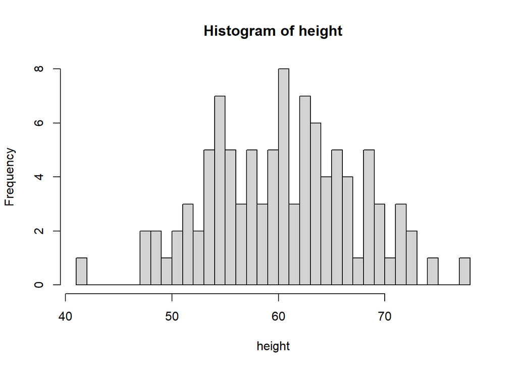

```r
height <- rnorm(n=100, mean= 60, sd = 6)
weight <- height*1.2 +  rnorm(n=100, mean= 10, sd = 6)
hist(height, breaks=50)
```

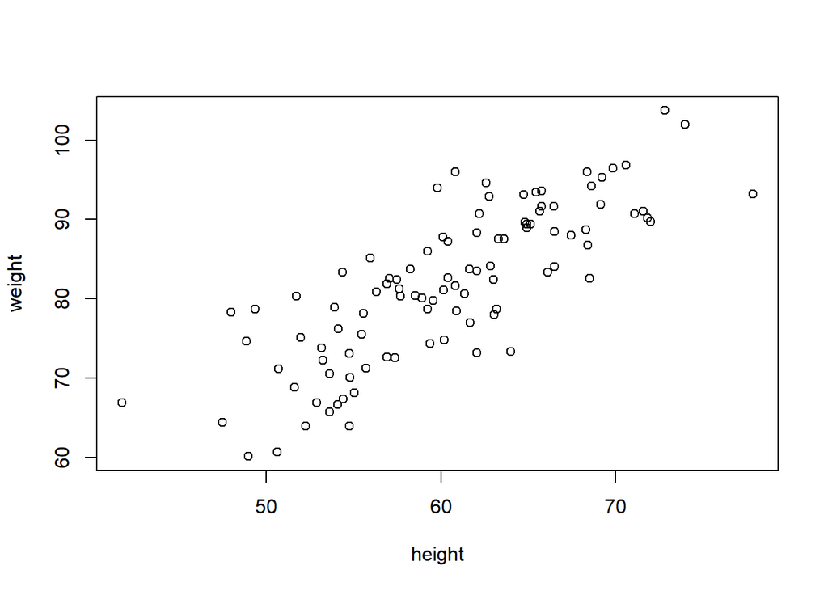

```r
plot(height, weight)
```